# Movement-based Habitat Selection Guidance

Brian D. Gerber, Casey Setash, Jacob S. Ivan. and Joseph M. Northrup

2024-01-10

## 1 Introduction

This vignette is associated with the manuscript titled, ‘A plain language review and guidance for modeling animal habitat-selection’. We will be demonstrating some of the points from the manuscript on fitting models to estimate parameters in a movement-based habitat selection function (HSF), which is also known as a step-selection function (SSF)). The scale of interest is the fourth-order of selection (e.g. selection along a track within a home range).

*Note:* some of the code-chunks are not automatically displayed. To show the code, select ‘show’.

## 2 Setup

### 2.1 Environment

First, load required R packages, source two local functions, and load an object containing spatial covariates.

```r
#Load packages
  library(geoR)
  library(circular)
  library(glmmTMB)
  library(raster)
  library(sp)
  library(survival)
  library(Rfast)
  library(remotes)
  library(plotrix)
  library(ggplot2)
  library(knitr)

# Install github repository
#    remotes::install_github("Pakillo/grateful")

  library(grateful)

# Source simulation function
  source("./functions/sim.ind.movement.hsf.r")

# Source bootstrapping function
  source("./functions/mean_ci_boot.r")

# Load spatial covariates stored in a save R object
  load("./data/Covs")
```

### 2.2 Simulate data

We will consider a habitat selection analysis of individuals along a movement track within a landscape (e.g., fourth-order of selection). Individuals’ effects are assumed to come from a distribution of effects that can be characterized by a mean and standard deviation (i.e., random effect).

```r
# Number of Sampled individuals (e.g., tracked via GPS telemetry)
  n.indiv = 30

# Define the true population-level coefficients
# and use these to simulate individual-level coefficients

# Selection against at population-level
# Low variation among individuals
  beta1.mu = -1
  beta1.sd = 0.2

  set.seed(543543)
  beta1=rnorm(n.indiv,
              mean = beta1.mu,
              sd = beta1.sd
  )
# No selection at population-level
# Wide variation among individuals
    beta2.mu = 0
    beta2.sd = 1

    set.seed(5435431)
    beta2=rnorm(n.indiv,
                mean = beta2.mu,
                sd = beta2.sd
    )

  # Selection for this feature at population-level
  # Low variation among individuals
    beta3.mu = 1
    beta3.sd = 0.2

    set.seed(1543543)
    beta3=rnorm(n.indiv,
                mean = beta3.mu,
                sd = beta3.sd
    )

# Combine coefficients and plot these values
  betas=data.frame(b1 = beta1,
                   b2 = beta2,
                   b3 = beta3)
```

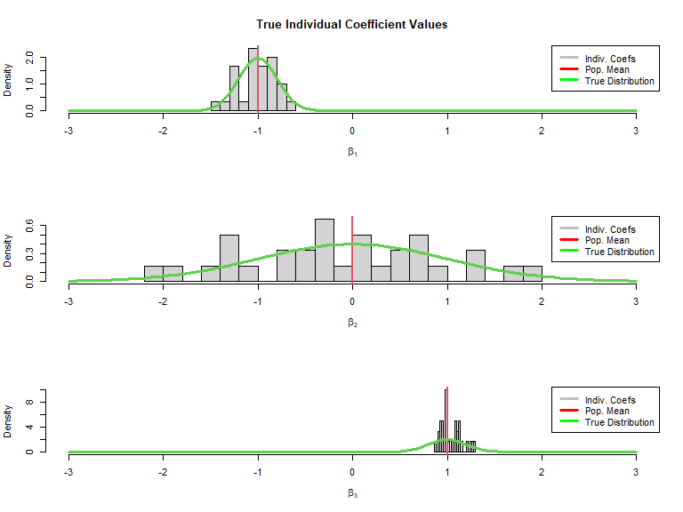

```r
  par(mfrow=c(3,1))
  hist(betas[,1],xlab=bquote(beta[1]),xlim=c(-3,3),main="True Individual Coefficient Values",breaks=10,freq=FALSE)
  abline(v=beta1.mu,lwd=2,col=2)
  curve(dnorm(x,beta1.mu,beta1.sd),lwd=3,col=3,add=TRUE)
  legend("topright",lwd=3,col=c("gray","red","green"),legend=c("Indiv. Coefs", "Pop. Mean","True Distribution"))

  hist(betas[,2],xlab=bquote(beta[2]),xlim=c(-3,3),main="",breaks=20,freq=FALSE)
  abline(v=beta2.mu,lwd=2,col=2)
  curve(dnorm(x,beta2.mu,beta2.sd),lwd=3,col=3,add=TRUE)
  legend("topright",lwd=3,col=c("gray","red","green"),legend=c("Indiv. Coefs", "Pop. Mean","True Distribution"))

  hist(betas[,3],xlab=bquote(beta[3]),xlim=c(-3,3),main="",breaks=20,freq=FALSE)
  abline(v=beta3.mu,lwd=2,col=2)
  curve(dnorm(x,beta3.mu,beta3.sd),lwd=3,col=3,add=TRUE)
  legend("topright",lwd=3,col=c("gray","red","green"),legend=c("Indiv. Coefs", "Pop. Mean","True Distribution"))
```

We have loaded spatial covariate data that can be found in the object `covs`. Lets look at the three covariates we will consider. The covariates included are the Euclidean distance to nearest development (`dist.dev`), the percent forest cover (`forest`), and the percent shrub cover (`shrub`). Each has been standardized to a mean of 0 and standard deviation of 1; this is a common procedure in linear modeling to help optimization algorithms converge to maximum likelihood estimates and to put each covaraite on the same scale (1 standard deviation of the covariate) so that coefficient magnitudes can be compared.

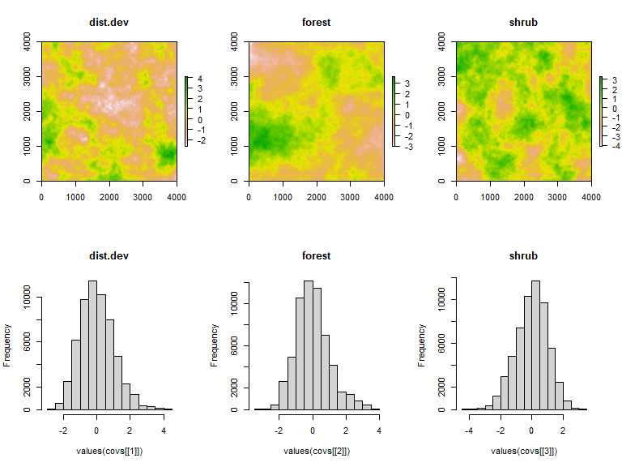

```r
# Combine into 1 raster stack
  covs = stack(covs[[1]],
               covs[[2]],
               covs[[3]]
               )

# Change the extent to be larger to accommodate more realistic movements
#  (not required but makes me feel better)
  extent(covs) = c(0,4000,0,4000)

# Names of variables
  names(covs[[1]]) = 'dist.dev'
  names(covs[[2]]) = 'forest'
  names(covs[[3]]) = 'shrub'

par(mfrow=c(2,3))
  plot(covs[[1]], main='dist.dev')
  plot(covs[[2]], main='forest')
  plot(covs[[3]], main='shrub')
  hist(values(covs[[1]]), main='dist.dev')
  hist(values(covs[[2]]), main='forest')
  hist(values(covs[[3]]), main='shrub')
```

Now, we will use the spatial covariates (`covs`) and true individual-level coefficients (`betas`) to create the linear combinations to create the true individual HSF (as a raster).

```r
  hsf.true = vector("list",n.indiv)
  for (i in 1:n.indiv){
    hsf.true[[i]] = (covs[[1]]*betas[i,1]+
                     covs[[2]]*betas[i,2]+
                     covs[[3]]*betas[i,3]
                     )
  }
```

We are now ready to simulate individual-level data. We will do this with the `sim.ind.movement.hsf` function that is sourced from the file with the same name.

```r
# Set number of available samples per used
  n.avail = 100

# Number of movements
  n.time = 400

# Number of possible steps to choose from at each iteration- these are not available locations, this is for the simulation of the movement path
  n.step = 400

# Population (across individual) turning angle parameters for von mises distribution
  angle.mean = 0
  angle.kappa = 0.0001

# Step length rate of exponential distribution
  step.rate = 0.01

# Simulate individual-level movement-based habitat selection data
  sims =  sim.ind.movement.hsf(hsf.true = hsf.true,
                               n.time = n.time,
                               n.step = n.step,
                               n.avail = n.avail,
                               angle.mean = angle.mean,
                               angle.kappa = angle.kappa,
                               step.rate = step.rate
                               )
```

Let’s look at one individual’s data. The `sims` object has two elements, one for x-y used locations )(`locs`) and one for the compiled data we will use to fit models (`indiv`). Within each of these lists are lists for each individual, one to `n.indiv`).

```r
  names(sims)
```

```
## [1] "indiv" "locs"
```

```r
# Individual 1 data
  head(sims$locs[[1]])
```

```
##      use.x    use.y
## 1 2007.386 2009.559
## 2 1970.555 1902.248
## 3 1939.713 2070.911
## 4 2003.961 2089.273
## 5 1964.091 1908.154
## 6 1970.880 1954.061
```

```r
  head(sims$indiv[[1]])
```

```
##     status strata    dist.dev     forest       shrub       step
## 1        1      1 -0.58591604 1.51212061 -0.23357781  12.080123
## 401      0      1  3.06594070 1.90153662 -0.78854177 652.887152
## 402      0      1  0.03532682 0.67724617 -0.09794270 118.846249
## 403      0      1 -0.53975331 1.62440620  0.05898945  33.013549
## 404      0      1 -0.71127578 1.31214563 -0.68346660   2.715337
## 405      0      1 -1.31842318 0.07685809 -1.07986956 244.388450
```

```r
  table(sims$indiv[[1]]$status)
```

```
##
##     0     1
## 40000   400
```

We see from this individual’s data frame that we have the columns: status, strata, dist.dev, forest, shrub, step. The column `status` is our response variable. A **1** indicates an animal location (used point) and a **0** indicates a potentially used location (available point). Each used location is paired with 100 available locations and are matched by the strata number (column `strata`). Each 1 and 0 have corresponding spatial variables, which we have called `dist.dev`, `forest`, and `shrub`. Each covariate has been standardized to have a mean of 0 and standard deviation of 1 (also called Normalizing). Note that we have a large available sample matched with each used location. This is correct. We need a large available sample (the 0’s) for each used location to approximate the true underlying spatio-temporal habitat selection model (specified via a weighted distribution; see Equation 1 of [Michelot et al. 2024](https://doi.org/10.1111/2041-210X.14248)).

Let’s look at one individual’s tracks on top of the true HSF.

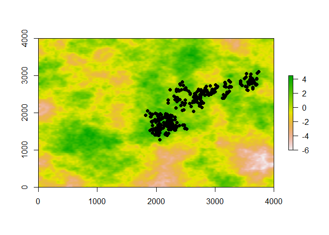

```r
#Plot the true HSF with locations for individual k
  k=10
  par(mfrow=c(1,1))
  plot(hsf.true[[k]])
  points(sims$locs[[k]]$use.x,
         sims$locs[[k]]$use.y,
         pch=16
         )
```

We now want to organize each individual’s simulated data into a single data frame to be able to fit all individuals together. We will use the objects `sims` and `sims2` below when we want to fit models to each individual separately and together, respectively. For `sims2`, we also need a new set of strata identifiers so that they are unique for each individual.

```r
# Combine data into a single data.frame
  sims2 = do.call("rbind", sims$indiv)
  head(sims2)
```

```
##     status strata    dist.dev     forest       shrub       step
## 1        1      1 -0.58591604 1.51212061 -0.23357781  12.080123
## 401      0      1  3.06594070 1.90153662 -0.78854177 652.887152
## 402      0      1  0.03532682 0.67724617 -0.09794270 118.846249
## 403      0      1 -0.53975331 1.62440620  0.05898945  33.013549
## 404      0      1 -0.71127578 1.31214563 -0.68346660   2.715337
## 405      0      1 -1.31842318 0.07685809 -1.07986956 244.388450
```

```r
  dim(sims2)
```

```
## [1] 1212000       6
```

```r
# Create ID vector for individual's data
LETTERS702 <- c(LETTERS, sapply(LETTERS, function(x) paste0(x, LETTERS)))

  ID = rep(LETTERS702[1:n.indiv],each=nrow(sims$indiv[[1]]))
  sims2$ID=ID

# Create new strata
  sims2$indiv.id.strata = paste0(sims2$ID,
                                 sims2$strata
                                 )
# The number of unique identifiers needed
# n.step*n.indiv
  length(unique(sims2$indiv.id.strata)) == n.step*n.indiv
```

```
## [1] TRUE
```

```r
  dim(sims2)
```

```
## [1] 1212000       8
```

```r
  head(sims2)
```

```
##     status strata    dist.dev     forest       shrub       step ID
## 1        1      1 -0.58591604 1.51212061 -0.23357781  12.080123  A
## 401      0      1  3.06594070 1.90153662 -0.78854177 652.887152  A
## 402      0      1  0.03532682 0.67724617 -0.09794270 118.846249  A
## 403      0      1 -0.53975331 1.62440620  0.05898945  33.013549  A
## 404      0      1 -0.71127578 1.31214563 -0.68346660   2.715337  A
## 405      0      1 -1.31842318 0.07685809 -1.07986956 244.388450  A
##     indiv.id.strata
## 1                A1
## 401              A1
## 402              A1
## 403              A1
## 404              A1
## 405              A1
```

## 3 Manuscript sections

We are now ready to fit models to estimate our movement-based habitat selection parameters and demonstrate points made in the manuscript. We have organized the sections below to match with the sections of the manuscript.

### 3.1 What is habitat?

Definitions only.

### 3.2 What is habitat selection?

Definitions only.

### 3.3 What is a habitat-selection function?

Definitions only.

We want to remind the reader of the nuance between a habitat selection function and the statistical model we will be fitting. The model we are fitting (as coded) and the true underlying model (weighted distribution of spatio-temporal model) is not the habitat selection function. The habitat selection function is a component of the model. We will approximate the true model in two different ways: 1) using a conditional logistic regression model and 2) using a Poisson regression model with stratum-specific fixed intercepts ([Muff et al. 2019](https://doi.org/10.1111/1365-2656.13087)). Each approach is used to estimate parameters within the movement-based habitat selection function. We will use the same data set to show the equivalence of the estimated parameters.

### 3.4 What about scale?

Definitions only.

In our data setup and analysis we will be estimating habitat selection at the fourth-order of the scales defined in Johnson (1980).

### 3.5 Why ‘habitat selection function’ and not ‘resource selection function’?

Definitions only.

### 3.6 Considering objectives and data collection

This is the hardest part of the whole habitat selection study. How do you decide on the what, where, and how many of sampling to answer the question at hand. Talk to many people. Ask questions to many people.

The modeling mentioned here is about differences between study goals, such as inference and prediction. Modeling for inference versus prediction is not a straightforward distinction. There are lots of opinions from the statistical folks (which are great and everyone should read them, e.g., [Shmueli, 2010](https://doi.org/10.1214/10-STS330) and [Scholz and Burner, 2022](https://arxiv.org/abs/2210.06927)) and the science philosophy folks. We reference the manuscript [Gerber and Northrup, 2020](https://esajournals.onlinelibrary.wiley.com/doi/full/10.1002/ecy.2953) in regards to when the study goal is preditiction. Associated with this manuscript is code in the Supporting Information file (ecy2953-sup-0004-DataS1.Zip) that pertains to optimizing for predicting spatial distributions of habitat selection (i.e., making a map). This process can jeopardize inference, e.g., make the interpretation of estimated effects unreliable. In contrast, if inference is sought you should think hard about a single model that includes the most important variables for the species and for your question that you want to consider so that estimated effects and measures of uncertainty are reliable ([Bolker 2023](https://doi.org/10.32942/X2Z01P), [Tredennick et al. 2021](https://esajournals.onlinelibrary.wiley.com/doi/full/10.1002/ecy.3336)).

The individual’s location data used to fit a movement-based HSF model is often sampled at a high-fix rate, relative to the animal’s speed. We curate our habitat selection data based on the movement process (e.g., step lengths and turning angles). In the above, we have simulated data with spatial locations at a standardized rate of movement and unit of time between movements. It is common for real-world telemetry data to have inconsistent times between consecutive spatial locations. It is important to standardize this time difference, otherwise the movement process parameters won’t be meaningful. For example, a time difference of 30 minutes and 60 minutes are likely to produce different step lengths and thus summarizing what is available on each used location will be compromised.

One way to standardize the time differences is by designing the data setup such that relocations are specified into tracks based on a threshold tolerance of allowable time between consecutive spatial locations (e.g., done in the R package amt; [Signer et al. 2019](https://doi.org/10.1002/ece3.4823)). In other words, resampling the GPS locations at regular intervals. Another way is to fit a continuous time movement model to then predict locations at a standarized interval (e.g., [Northrup et al. 2018](https://doi.org/10.1111/gcb.13037) and [Johnson et al. 2008](https://doi.org/10.1890/07-1032.1))

### 3.7 What are habitat-selection functions used for?

In this section, we discuss some mechanics of inference and prediction, as in interpreting coefficients and predicting relative habitat selection. We will walk through the basics here, but refer the reader to full in depth coverage in [Fieberg et al. 2021](https://doi.org/10.1111/1365-2656.13441) and [Avgar et al. 2017](https://doi.org/10.1002/ece3.3122). We also mention the goal of using habitat selection to predict animal abundance. Demonstrating this is beyond our work. We suggest starting with the reading of section 1.6, “When is species density a reliable reflection of habitat suitability?” of [Matthiopoulos, Fieberg, and Aarts, 2023](http://hdl.handle.net/11299/217469).

#### 3.7.1 Inference

Let’s fit a model to one individual’s matched used and available data and discuss the estimated movement-based HSF coefficients. Remember, we have setup an available sample to be paired with a used location to control for the issues of serial dependence or autocorrelation between sequential relocations. This process has also hopefully better defined what is truly accessible to the individual at each location based on their movement dynamics (specifically, turning angle and step-length within a standardized time period). By doing this, we have focused our attention on the dynamic selection of habitat as the animal movemees through the landscape.

```r
# We will use data from individual 1
  indiv.data1 = sims$indiv[[1]]

# Let's look at the data to remind us what it is
  head(indiv.data1)
```

```
##     status strata    dist.dev     forest       shrub       step
## 1        1      1 -0.58591604 1.51212061 -0.23357781  12.080123
## 401      0      1  3.06594070 1.90153662 -0.78854177 652.887152
## 402      0      1  0.03532682 0.67724617 -0.09794270 118.846249
## 403      0      1 -0.53975331 1.62440620  0.05898945  33.013549
## 404      0      1 -0.71127578 1.31214563 -0.68346660   2.715337
## 405      0      1 -1.31842318 0.07685809 -1.07986956 244.388450
```

We are now ready to approximate our true model using two difference approaches: the conditional logistic regression model and the Poisson regression model.

First, we can accomplish the first apporach using the `clogit function` in package `survival`. We have related our response variable of the used and available sample (`status`) to our covariates and tell the model how the 1’s and 0’s are matched with the variable `strata`, which is part of the linear equation but wrapped by an internal function `strata`. Note that the variable combinations are one of an additive model, as opposed to having interactions.

```r
  model1 = clogit(status ~ dist.dev + forest + shrub + strata(strata),
                  data = indiv.data1
                  )

# Look at estimated coefficients
  summary(model1)
```

```
## Call:
## coxph(formula = Surv(rep(1, 40400L), status) ~ dist.dev + forest +
##     shrub + strata(strata), data = indiv.data1, method = "exact")
##
##   n= 40236, number of events= 400
##    (164 observations deleted due to missingness)
##
##              coef exp(coef) se(coef)      z Pr(>|z|)
## dist.dev -0.78316   0.45696  0.08862 -8.838  < 2e-16 ***
## forest   -0.42742   0.65219  0.12521 -3.413 0.000641 ***
## shrub     0.84170   2.32031  0.07845 10.729  < 2e-16 ***
## ---
## Signif. codes:  0 '***' 0.001 '**' 0.01 '*' 0.05 '.' 0.1 ' ' 1
##
##          exp(coef) exp(-coef) lower .95 upper .95
## dist.dev    0.4570      2.188    0.3841    0.5436
## forest      0.6522      1.533    0.5103    0.8336
## shrub       2.3203      0.431    1.9896    2.7060
##
## Concordance= 0.722  (se = 0.011 )
## Likelihood ratio test= 274.9  on 3 df,   p=<2e-16
## Wald test            = 209  on 3 df,   p=<2e-16
## Score (logrank) test = 208.9  on 3 df,   p=<2e-16
```

Let’s first consider the `Intercept`. OH, there is no intercept. That is correct in these models and for our purposes, the intercepts have no biological meaningful interpretation and thus are not necessary.

Next, we have estimated the effect of `dist.dev` as -0.78. This estimate is negative, indicating that as the value of `dist.dev` increases from its mean (defined at 0) habitat selection decreases, given that the values of `forest` and `shrub` (the other variables in the model) are held at their mean (0). In other words, habitat use relative to what is available to this individual (as we defined it dynamically on a movement track) decreases the further from development. That’s a lot of qualifiers to understand this estimate. These are important though. In terms of evidence of an effect, we can say that at a defined Type I error of 0.05, this is a [statistically clear](https://doi.org/10.1111/2041-210X.13159) effect that is not likely zero. The evidence of this is the very small p-value of 9.772012^{-19}.

Next, we have estimated the effect of `forest` as -0.43. This estimate is negative, indicating that as the value of `forest` increases from its mean (defined at 0) habitat selection decreases relative to what is available to this individual (assuming `dist.dev` and `shrub` are at their mean). At our defined Type I error, this is a statistically clear effect that it is not likely zero (p-value = 6.413425^{-4}).

Next, we have estimated the effect of `shrub` as 0.84. This estimate is positive, indicating that as the value of `shrub` increases from its mean (defined at 0) habitat selection increases relative to what is available to this individual (assuming `dist.dev` and `forest` are at their mean). At our defined Type I error, this is a statistically clear effect that is not likely zero (p-value = 7.4494248^{-27}).

The above output also conveniently shows us the exponentiation of each coefficient. This is helpful because `exp(coefficient)` “quantifies the relative intensity of use of two locations that differ by 1 standard deviation unit of [the variable] but are otherwise equivalent (i.e. they are equally available and have the same values of all other habitat covariates)” ([Fieberg et al. 2021](https://doi.org/10.1111/1365-2656.13441)).

##### 3.7.1.1 **Other Functions**

We can estimate the same parameters and get the very same estimates with other functions that implement the conditional logistic regression model. For example, the functions `fit_clogit` or `fit_ssf` in the `amt` package. These are wrapper functions for using the `survival clogit` function. We can see what the function is doing:

```r
amt::fit_ssf
```

```
## function (data, formula, more = NULL, summary_only = FALSE, ...)
## {
##     if (!any(grepl(pattern = "^strata\\(.+\\)$", attr(terms(formula),
##         "term.labels")))) {
##         stop("No strata is provided, please make sure the formula includes a strata.")
##     }
##     m <- survival::clogit(formula, data = data, ...)
##     if (summary_only) {
##         m <- list(model = broom::tidy(m), sl_ = attributes(data)$sl_,
##             ta_ = attributes(data)$ta_, more = more)
##         class(m) <- c("fit_clogit_summary_only", "fit_clogit",
##             class(m))
##     }
##     else {
##         m <- list(model = m, sl_ = attributes(data)$sl_, ta_ = attributes(data)$ta_,
##             more = more)
##         class(m) <- c("fit_clogit", class(m))
##     }
##     m
## }
## <bytecode: 0x000002b147fa02a8>
## <environment: namespace:amt>
```

Now lets use these functions to estimate the same coefficients as we did with `clogit`:

```r
  model1.amt1 = amt::fit_ssf(data = indiv.data1,
                             formula = status ~ dist.dev + forest +
                                                shrub + strata(strata),
                             model=TRUE
                            )

  model1.amt2 = amt::fit_clogit(data = indiv.data1,
                                formula = status ~ dist.dev+forest+
                                                   shrub + strata(strata),
                                model=TRUE
                                )

  coef(model1)
```

```
##   dist.dev     forest      shrub
## -0.7831639 -0.4274160  0.8417028
```

```r
  coef(model1.amt1)
```

```
##   dist.dev     forest      shrub
## -0.7831639 -0.4274160  0.8417028
```

```r
  coef(model1.amt2)
```

```
##   dist.dev     forest      shrub
## -0.7831639 -0.4274160  0.8417028
```

We can see the estimated coefficients are all the same.

##### 3.7.1.2 **Poisson model equivalence to the conditional logistic model**

[Muff et al. 2019](https://doi.org/10.1111/1365-2656.13087) demonstrated the equivalence between the conditional logistic regression model and Poisson regression model with stratum-specific fixed intercepts. We can fit this model using the `glmmTMB` package, which has computational advantages over fitting the conditional logistic regression model. The key to this implementation is that we want to include stratum as part of the linear combination of variables wrapped in the function `strata` to estimate fixed effect intercepts, or do the same procedure in a random effect implementation but without shrinkage by fixing the variance to a large value.

```r
# Fit the model with fixed effect stratum-specific intercepts
    model1.tmb = glmmTMB(status ~ dist.dev + forest +
                                  shrub + strata(strata),
                         data = indiv.data1,
                         family = poisson
                         )

# Or using a random effect with fixed variance
    model1.tmb2 = glmmTMB(status ~ dist.dev + forest +
                                   shrub + (1| strata),
                          data = indiv.data1,
                          family = poisson,
                          doFit = FALSE
                          )

# Make the intercept variance large and fixed
  model1.tmb2$parameters$theta[1] = log(1e3)

# Tell glmmTMB to not estimate the variance of the intercept
  model1.tmb2$mapArg = list(theta=factor(c(NA)))

# Now ready to fit the model
  model1.tmb2 = glmmTMB:::fitTMB(model1.tmb2)
```

Lets compare the coefficient estimates from these two model fits with one of the clogit fits from above.

**Poisson random intercept (fixed variance)**

```r
knitr::kable(summary(model1.tmb2)[[6]]$cond[2:4,],digits=3)
```

|  | Estimate | Std. Error | z value | Pr(>\|z\|) |
| --- | --- | --- | --- | --- |
| dist.dev | -0.783 | 0.089 | -8.838 | 0.000 |
| forest | -0.427 | 0.125 | -3.414 | 0.001 |
| shrub | 0.842 | 0.078 | 10.729 | 0.000 |

**Poisson Fixed effect**

```r
knitr::kable(summary(model1.tmb)[[6]]$cond[2:4,],digits=3)
```

|  | Estimate | Std. Error | z value | Pr(>\|z\|) |
| --- | --- | --- | --- | --- |
| dist.dev | -0.783 | 0.089 | -8.838 | 0.000 |
| forest | -0.427 | 0.125 | -3.414 | 0.001 |
| shrub | 0.842 | 0.078 | 10.729 | 0.000 |

**clogit model**

```r
knitr::kable(summary(model1)[[7]][,-2],digits=3)
```

|  | coef | se(coef) | z | Pr(>\|z\|) |
| --- | --- | --- | --- | --- |
| dist.dev | -0.783 | 0.089 | -8.838 | 0.000 |
| forest | -0.427 | 0.125 | -3.413 | 0.001 |
| shrub | 0.842 | 0.078 | 10.729 | 0.000 |

We find the same exact estimates. Woohoo!

Note that in the fixed effect implementation (model1.tmb) we are actually estimating a lot of partial intercepts (strata). However, we can ignore them as they are not of interest, just a means to an end. That is why in the above code, we are limiting the estimates from the summary with the part `cond[2:4,]`

##### 3.7.1.3 **Relative Selection**

How do we quantitatively evaluate two locations in terms of habitat selection using our model results? We can do so using Equation 8 of [Fieberg et al. 2021](https://doi.org/10.1111/1365-2656.13441).

Perhaps we want to compare a location that is very near development (dist.dev = -2) at high forest and shrub cover (forest = 2, shrub = 2) with that of a location far from development (dist.dev = 2) and also at high forest but low shrub cover (forest = 2, shrub = -2).

```r
# Get estimates
  coef = coef(model1)

# Relative Selection
  RS = exp(-2*coef[1] + 2*coef[2] + 2*coef[3]) / exp(2*coef[1] + 2*coef[2] + -2*coef[3])
  RS
```

```
## dist.dev
##  664.787
```

##### 3.7.1.4 **Relative Selection Strength**

[Avgar et al. 2017](https://doi.org/10.1002/ece3.3122) refers to the relative selection strength (RSS) as the exponentiation of each coefficient.

For example,

```r
# Coefficient for forest
  exp(coef[2])
```

```
##    forest
## 0.6521922
```

Given two locations that differ by 1 standard deviation of percent forest (`forest`), but are otherwise equal, this individual would be 0.65 as likely to choose the location with higher `forest`, or equivalently, 1.53 times more likely to choose the location with the lower `forest.`

#### 3.7.2 Prediction

For convenience, we can use the `log_rss` function of the `amt` package to predict the log relative strength when comparing many locations with differing covariates values. To do so, we need create two data frames of the covariate combinations of interest: `s1` and `s2`.

```r
# Make a new data.frame for s1
  s1 = data.frame(
          dist.dev = seq(from = -2, to = 2, length.out = 100),
          forest = 0,
          shrub = 0,
          strata = 1 # needed, but the number is irrelevant
          )

# data.frame for s2
  s2 = data.frame(
         dist.dev = 0, # mean of dist.dev
         forest = 0,
         shrub = 0,
         strata = 1 # needed, but the number is irrelevant
    )

# Calculate log-RSS
  lr2 = amt::log_rss(model1.amt1,
                     s1,
                     s2,
                     ci = "se",
                     ci_level = 0.95
                     )
```

```r
  plot(lr2,lwd=3)
```

```
## Guessing x_vars:
##   x_var1 = dist.dev
##   x_var2 = forest
```

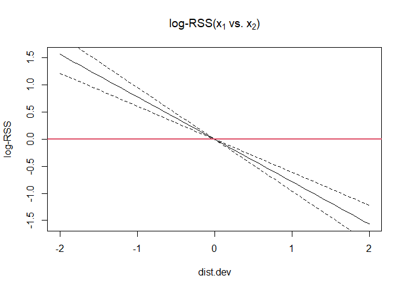

```r
  lines(lr2$df$dist.dev_x1,lr2$df$lwr,lty=2)
  lines(lr2$df$dist.dev_x1,lr2$df$upr,lty=2)
  abline(h=0,lwd=2,col=2)
```

We have predicted a mean (solid line) and 95% confidence intervals (dotted) of the log-RSS between each value of s1 relative to s2. These locations differ only in their values of `dist.dev`, and the log-RSS is equal to 0 when the two locations are identical (i.e., dist.dev = 0). Above the zero line the individual is selected more than available and below the zero line they are selecting less than available.

### 3.8 Traditional HSF or SSF?

In fitting these data using a movement-based HSF, we are simultaneously trying to account for two important assumptions. First, we are limiting what is available to the animal at each used location by defining the availability as around this area and informed by the movement parameters of step-length (how far is the animal likely to go) and step-length (what direction is the animal likely to go). Second, we are defining our data setup to deal with the fine-scale sequential dependency of consecutive relocations and minimize issues of autocorrelation. If there is interest in using these same data at a lower selection-order, its important to consider the issues of autocorrelation and availability. In the manuscript, we provide two options for doing so.

### 3.9 The data generating model and the model being fit

Context only.

### 3.10 The model being approximated

It is the responsibility of the researcher to make sure their modeling process is done such that they are approximating the true underlying model well. To demonstrate this, we will consider how estimated coefficients change with increasing numbers of available samples per each used location.

```r
# Grab individual one's data
  indiv.dat1 = sims$indiv[[1]]

#Size of available samples per used locaiton
  n.avail2 = seq(2,100,by=2)

#Save coefficients
  coef.save = NULL

#Loop across available sample sizes
  for(i in 1:length(n.avail2)){
  #Loop through each used location and reduce the number of available samples
    ind.dat=NULL
  for(j in 1:n.step){
    index = which(indiv.dat1$strata==j)
    #Get the used locaiton and the sub-sampled availables
    ind.dat.temp = indiv.dat1[index,][1:(n.avail2[i]+1),]
    ind.dat = rbind(ind.dat,ind.dat.temp)
  }

# fit model with data
    model.temp = clogit(status ~ dist.dev + forest + shrub + strata(strata),
                      data = ind.dat
                      )
  coef.save = rbind(coef.save,
                    coef(model.temp)
                    )
}

coef.save = data.frame(n.avail2,coef.save)
colnames(coef.save) = c("N.Avail","beta1","beta2","beta3")
```

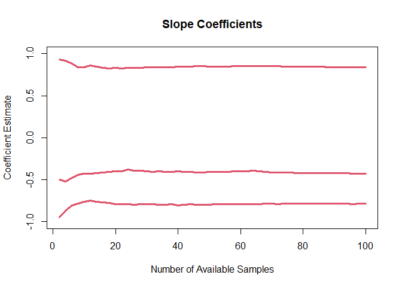

```r
par(mfrow=c(1,1))
plot(coef.save$N.Avail, coef.save$beta1,lwd=3,type="l",col=2,ylim=c(-01,1),
     main="Slope Coefficients",
     xlab="Number of Available Samples",ylab="Coefficient Estimate")
lines(coef.save$N.Avail, coef.save$beta2,lwd=3,col=2)
lines(coef.save$N.Avail, coef.save$beta3,lwd=3,col=2)
```

```r
#knitr::kable(coef.save,digits=3)
```

Another way to look at this sensitivity is by showing the variability of the coefficients within and across different sizes of available samples.

```r
# Grab individual one's data
  indiv.dat1 = sims$indiv[[1]]

# Size of available samples per used locaiton
  n.avail2 = c(2,10,20,40,60,80,100)

# Number of sample replications
 n.sample = 20

# Save coefficients
  coef.save = NULL

#Loop across available sample sizes
  for(i in 1:length(n.avail2)){

  #re-sample each available sample size 20 times
  for (z in 1:n.sample){
  #Loop through each used location and reduce the number of available samples
    ind.dat = NULL
  for(j in 1:n.step){
    index = which(indiv.dat1$strata==j)
    #Get the used locaiton and the sub-sampled availables
    rand.sample = sample(index[-1],n.avail2[i])
    ind.dat.temp = indiv.dat1[c(index[1],rand.sample),]
    ind.dat = rbind(ind.dat,ind.dat.temp)
  } # end j step loop

# fit model with data
    model.temp = clogit(status ~ dist.dev + forest + shrub + strata(strata),
                      data = ind.dat
                      )
  coef.save = rbind(coef.save,
                   coef(model.temp)
                  )
  }#end z sample loop
}#end i loop
```

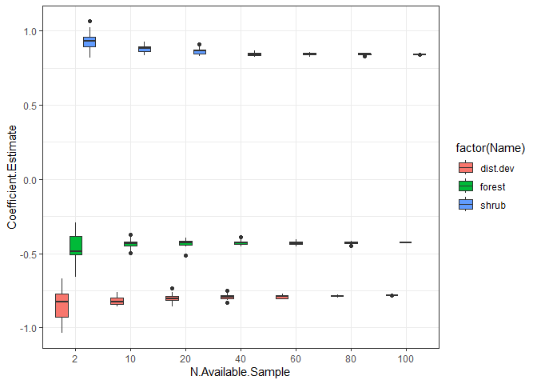

```r
one = data.frame(N.Avail=rep(n.avail2,each=n.sample),
                 Sample=rep(1:n.sample,length(n.avail2)),
                 beta = coef.save[,1]
                )
two = data.frame(N.Avail=rep(n.avail2,each=n.sample),
                 Sample=rep(1:n.sample,length(n.avail2)),
                 beta = coef.save[,2]
                )
three = data.frame(N.Avail=rep(n.avail2,each=n.sample),
                 Sample=rep(1:n.sample,length(n.avail2)),
                 beta = coef.save[,3]
                )
plot.data = rbind(one,two,three)
plot.data$Name = c(rep("dist.dev",nrow(one)),
                   rep("forest",nrow(one)),
                   rep("shrub",nrow(one))
                 )

plot.data$N.Avail = as.factor(plot.data$N.Avail)


colnames(plot.data) = c("N.Available.Sample","Sample","Coefficient.Estimate","Name")

ggplot2::ggplot(plot.data, aes(N.Available.Sample, Coefficient.Estimate, fill=factor(Name))) +
  theme_bw()+
  geom_boxplot()
```

We see more easily in this plot that there is high variability in the estimated coefficients when the available sample is small. This variability decreases as the available sample grows, showing how the estimates are stabilizing.

### 3.11 Individuals

We should *a priori* assume there is individual variation in habitat selection estimates. This variation is masked when data are pooled. Lets consider the implications of pooling all data vs fitting a model separately to each individual. Note that the object `sims2` has all the individuals combined into a single data frame. We will use the `glmmTMB` function to fit the model using the Poisson model regression approach with strata as a random effect, but that is not really estimated. This is fast and stable implementation.

```r
# Pooled model - no consideration of individual variability
  model.pool = glmmTMB(status ~ dist.dev + forest + shrub +
                               (1|indiv.id.strata),
                         data=sims2,
                         family=poisson,
                         doFit = FALSE
                         )
  model.pool$parameters$theta[1] = log(1e3)
  model.pool$mapArg = list(theta=factor(c(NA)))
  options(warn=-1)
  model.pool = glmmTMB:::fitTMB(model.pool)
  options(warn=0)
# Look at estimates when pooling the data
  summary(model.pool)
```

```
##  Family: poisson  ( log )
## Formula:          status ~ dist.dev + forest + shrub + (1 | indiv.id.strata)
## Data: sims2
##
##       AIC       BIC    logLik  deviance  df.resid
##  294015.2  294063.1 -147003.6  294007.2   1173566
##
## Random effects:
##
## Conditional model:
##  Groups          Name        Variance Std.Dev.
##  indiv.id.strata (Intercept) 1e+06    1000
## Number of obs: 1173570, groups:  indiv.id.strata, 12000
##
## Conditional model:
##             Estimate Std. Error z value Pr(>|z|)
## (Intercept) -5.36235    9.12872   -0.59 0.556925
## dist.dev    -0.67471    0.01513  -44.60  < 2e-16 ***
## forest      -0.05418    0.01594   -3.40 0.000679 ***
## shrub        0.86746    0.01513   57.35  < 2e-16 ***
## ---
## Signif. codes:  0 '***' 0.001 '**' 0.01 '*' 0.05 '.' 0.1 ' ' 1
```

```r
# Separate models to each individual
  indiv.fit = lapply(sims[[1]],FUN=function(x){
                  temp=glmmTMB(status ~ dist.dev+forest+shrub + (1|strata),
                                 data=x,
                                 family=poisson,
                               doFit = FALSE
                                 )

              temp$parameters$theta[1] = log(1e3)
              temp$mapArg = list(theta=factor(c(NA)))
              options(warn=-1)
              temp = glmmTMB:::fitTMB(temp)
              options(warn=0)
              temp
              })
```

In the pooled data, we see that the standard errors of the coefficients and p-values are very small. We are using a lot of information, assuming no variation among individuals, and thus assuming every individual’s effects can be characterized by these estimates. Now let’s look at just two individual’s estimates when fitting separate models.

```r
summary(indiv.fit[[2]])
```

```
##  Family: poisson  ( log )
## Formula:          status ~ dist.dev + forest + shrub + (1 | strata)
## Data: x
##
##      AIC      BIC   logLik deviance df.resid
##   9794.9   9829.4  -4893.5   9786.9    40396
##
## Random effects:
##
## Conditional model:
##  Groups Name        Variance Std.Dev.
##  strata (Intercept) 1e+06    1000
## Number of obs: 40400, groups:  strata, 400
##
## Conditional model:
##             Estimate Std. Error z value Pr(>|z|)
## (Intercept) -5.56072   50.00007  -0.111    0.911
## dist.dev    -0.69182    0.08691  -7.960 1.72e-15 ***
## forest       0.48584    0.08935   5.438 5.40e-08 ***
## shrub        0.89271    0.09021   9.895  < 2e-16 ***
## ---
## Signif. codes:  0 '***' 0.001 '**' 0.01 '*' 0.05 '.' 0.1 ' ' 1
```

```r
summary(indiv.fit[[10]])
```

```
##  Family: poisson  ( log )
## Formula:          status ~ dist.dev + forest + shrub + (1 | strata)
## Data: x
##
##      AIC      BIC   logLik deviance df.resid
##   9867.4   9901.8  -4929.7   9859.4    40275
##
## Random effects:
##
## Conditional model:
##  Groups Name        Variance Std.Dev.
##  strata (Intercept) 1e+06    1000
## Number of obs: 40279, groups:  strata, 400
##
## Conditional model:
##              Estimate Std. Error z value Pr(>|z|)
## (Intercept) -0.007679  50.000055   0.000        1
## dist.dev    -0.519150   0.077938  -6.661 2.72e-11 ***
## forest       0.464137   0.086106   5.390 7.03e-08 ***
## shrub        0.841780   0.087168   9.657  < 2e-16 ***
## ---
## Signif. codes:  0 '***' 0.001 '**' 0.01 '*' 0.05 '.' 0.1 ' ' 1
```

First, notice that the estimated effects are a bit different than the pooled estimates. Importantly, also notice that the standard errors and p-values are larger.

Now lets look at all the estimates together.

```r
# Extract pooled estimates with Confidence intervals
 pool.effect = broom.mixed::tidy(model.pool, effects = "fixed", conf.int = TRUE)

# Extract separate individual estimates
 indiv.coef = lapply(indiv.fit,FUN=function(x){
                     temp=broom.mixed::tidy(x, effects = "fixed",
                                            conf.int = TRUE
                                            )
                     data.frame(temp[-1,c(4,8,9)])
 })

# These are all coefs (1:3) for each individual 1:n.indiv
  estimates = sapply(indiv.coef,"[[",1)
  LCI = sapply(indiv.coef,"[[",2)
  UCI = sapply(indiv.coef,"[[",3)
```

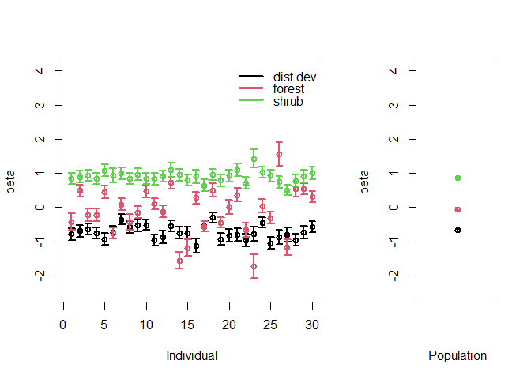

```r
layout(matrix(c(1,2), nrow = 1, ncol = 2, byrow = TRUE),
       width=c(2,1))
plotCI(1:n.indiv,
       y=estimates[1,],
       ui=UCI[1,],
       li=LCI[1,],
       ylab="beta",
       xlab="Individual",
       lwd=2,
       ylim=c(-2.5,4)
)
 legend("topright",lwd=3,col=c(1,2,3),
        legend=c("dist.dev","forest","shrub"),box.lty=0,y.intersp=0.8)

plotCI(1:n.indiv,y=estimates[2,],
       ui=UCI[2,],
       li=LCI[2,],
       ylab="beta_1",
       xlab="Individual",
       lwd=2,
       col=2,
       add=TRUE
       )
plotCI(1:n.indiv,y=estimates[3,],
       ui=UCI[3,],
       li=LCI[3,],
       ylab="beta_1",
       xlab="Individual",
       lwd=2,
       col=3,
       add=TRUE
       )
plotCI(c(1,1,1),y=pool.effect$estimate[2:4],
       xlim=c(0.95,1.05),
       ui=pool.effect$conf.high[2:4],
       li=pool.effect$conf.low[2:4],
       ylab="beta",
       xlab="Population",
       lwd=2,
       ylim=c(-2.5,4),
       col=c(1,2,3),
       xaxt='n'
       )
```

The plot on the right are the pooled estimates for $\beta_1$ (black; dist.dev), $\beta_2$ (red; forest), and $\beta_3$ (green; shrub). The plot on the left are each individual’s estimates (colored the same). By ignoring individual variation, we are a much too confident in our estimates of uncertainty and are ignoring a lot of clear variation by individual. The pooled estimate’s certainty is do to pseudoreplication - the treating a sub-unit (each location) as are main unit of replication. Our true unit of replication is the individual.

Since our sample sizes for each individual are equal, we see that the pooled estimates generally relate to the average of each estimate across all individuals. When the number of used locations varies by individual this won’t be the case. The individuals with more used locations will disproportionately influence the pooled estimates.

#### 3.11.1 Sample size

The code for implementing the methods of [Street et al. 2021](https://doi.org/10.1111/2041-210X.13701) can be found at [figshare](https://figshare.com/articles/dataset/Datasets_and_Code_zip/11910831).

You can also find an implementation of these methods to calculate the number of used locations to determine statistical clarity of a hypothesized spatial effect in the [Traditional HSF example] (https://bgerber123.github.io/hsfguide/TraditionalHSF.html#311_Individuals)

### 3.12 Population inference

If we are interested in obtaining inference to the individual- and population-level effects, we can consider bootstrapping the results from individual models or jointly fitting a single model with a random effect across individuals. We will first consider the bootstrapping method. Second, we will demonstrate the use of random intercepts and slopes, as well as how to fix the variance of the random intercept so there is no shrinkage.

#### 3.12.1 Bootstrapping

Bootstrapping is a resampling technique used often in statistics to obtain a sampling distribution of possible values. We will resample the individual-level coefficents to estimate the population-level mean and variation.

The core functions for bootstrapping are adopted from Dr. Bastille-Rousseau’s github repository for the R package [IndRSA](https://github.com/BastilleRousseau/IndRSA/).

We first need to get all estimated coefficients from each individual.

```r
  coef.list = lapply(indiv.fit,FUN=function(x){fixef(x)[[1]]})

  coef.df=do.call(rbind.data.frame, coef.list)
  colnames(coef.df)=names(fixef(indiv.fit[[1]])[[1]])

# Remove intercept
  coef.df = coef.df[,-1]

# Add name (could be modified to keep track if animals have an ID)
  coef.df$name = 1:nrow(coef.df)

# Frequency could be greater than one if there were multiple estimates of a single individual, perhaps across years
  coef.df$freq = 1
```

We are ready to bootstrap the coefficient estimates.

```r
#How many bootstraps to do? More will lead to results with less error
  nboot = 1000

#Which columns have coefficients in coef.df
  col.locs=1:3

  boot=list()
  for(i in 1:nboot){
    boot[[i]]=apply(
                     coef.df[sample(nrow(coef.df), nrow(coef.df),
                                    replace=TRUE,
                                    prob=coef.df$freq),
                             col.locs
                             ],
                     2,
                     median,
                     na.rm=TRUE
                     )
  }
```

We now want to summarize our bootstrapped results. The population mean and 95% lower and upper confidence intervals are outputted.

```r
# Source summary function
  boot.pop.esimates=mean_ci_boot(boot)
  rownames(boot.pop.esimates)=c("dist.dev","forest","shrub")
  knitr::kable(boot.pop.esimates,digits=3)
```

|  | Mean | LCI | UCI |
| --- | --- | --- | --- |
| dist.dev | -0.756 | -0.825 | -0.656 |
| forest | -0.058 | -0.370 | 0.289 |
| shrub | 0.905 | 0.840 | 0.951 |

#### 3.12.2 Random effects across individuals

##### 3.12.2.1 Random intercept only model

The most common use of random effects in habitat selection analysis is the use of a random intercept. As described in the manuscript, this does not account for variation in the slope coefficients, which is problematic.

While we are using common language in describing the models and model fitting process, note that there are very different meanings of `fixing a parameter` (i.e., random intercept variance) versus a `fixed effect`. The former refers to setting a parameter at a given value and is not estimated. The later refers to a description of a type of parameter that is estimated.

```r
# Setup HSF with Poisson regression approximation - random intercept model
# indiv.id.strata indicates individuals and strata and there the variance is fixed so there is no shrinkage
  re_int = glmmTMB(status ~ dist.dev + forest + shrub  +
                             (1|indiv.id.strata),
                    family=poisson ,
                    data = sims2,
                    doFit=FALSE
                    )

# Make the intercept variance large and fixed (i.e., do not estimate).
  re_int$parameters$theta[1] = log(1e3)

# Tell glmmTMB to not estimate the variance of the intercept
  re_int$mapArg = list(theta=factor(c(NA)))

# Now ready to fit the model
  options(warn=-1)
  re_int = glmmTMB:::fitTMB(re_int)
  options(warn=0)
```

The fixed components - these are the mean effects when pooling all individuals.

```r
  fixef(re_int)
```

```
##
## Conditional model:
## (Intercept)     dist.dev       forest        shrub
##    -5.36235     -0.67471     -0.05418      0.86746
```

The random components- these are the effect differences for each variation from the mean estimated (referred to as the fixed effect in the ‘conditional model’ statement). For this model we will have many many intercepts. Specifically, we will have a unique value for the number of individuals times the number of strata within individual

```r
  head(ranef(re_int)[[1]][[1]])
```

```
##      (Intercept)
## A1    0.26258121
## A10  -0.07350571
## A100  0.19616214
## A101 -0.40665805
## A102 -0.40542909
## A103 -0.21143664
```

```r
  summary(re_int)
```

```
##  Family: poisson  ( log )
## Formula:          status ~ dist.dev + forest + shrub + (1 | indiv.id.strata)
## Data: sims2
##
##       AIC       BIC    logLik  deviance  df.resid
##  294015.2  294063.1 -147003.6  294007.2   1173566
##
## Random effects:
##
## Conditional model:
##  Groups          Name        Variance Std.Dev.
##  indiv.id.strata (Intercept) 1e+06    1000
## Number of obs: 1173570, groups:  indiv.id.strata, 12000
##
## Conditional model:
##             Estimate Std. Error z value Pr(>|z|)
## (Intercept) -5.36235    9.12872   -0.59 0.556925
## dist.dev    -0.67471    0.01513  -44.60  < 2e-16 ***
## forest      -0.05418    0.01594   -3.40 0.000679 ***
## shrub        0.86746    0.01513   57.35  < 2e-16 ***
## ---
## Signif. codes:  0 '***' 0.001 '**' 0.01 '*' 0.05 '.' 0.1 ' ' 1
```

**A random intercepts only model is not recommended.** This is because we are not dealing with the expected variation of responses to hypothesized spatial factors across individuals.

#### 3.12.3 Random intercept and slopes model

This is the recommended model structure using random effects.

```r
#Fit RSF with intercept and slopes with random effect
  re_int_slopes =  glmmTMB(status ~ -1 + dist.dev + forest + shrub  +
                                    (1|indiv.id.strata) +
                                    (0+dist.dev|ID) + (0+forest|ID) +
                                    (0+shrub|ID),
                            family = poisson,
                            data = sims2,
                            doFit = FALSE
                            )
# make the intercept variance large and fixed (i.e., do not estimate).
  re_int_slopes$parameters$theta[1] = log(1e3)

# Tell glmmTMB to not estimate the variance of intercept, but
# to do so for the other three variables
  re_int_slopes$mapArg = list(theta=factor(c(NA,1:3)))

# Now ready to fit the model
  options(warn=-1)
  re_int_slopes = glmmTMB:::fitTMB(re_int_slopes)
  options(warn=0)
```

Let’s look at the results. Here, we have the population-level (across) individual-level means. So, generally, we see that at this level the estimated coefficients are negative, near zero, and positive for `dist.dev`, `forest`, and `shrub`, respectively.

```r
  fixef(re_int_slopes)
```

```
##
## Conditional model:
## dist.dev    forest     shrub
##  -0.7319   -0.1187    0.8931
```

We can get estimates with 95% confidence intervals as well. We see that these statements are supported statistically in the above statement based on examining whether intervals include 0 or not.

```r
  broom.mixed::tidy(re_int_slopes,
                    effects = "fixed",
                    conf.int = TRUE)[,c(3,4,8,9)]
```

```
## # A tibble: 3 × 4
##   term     estimate conf.low conf.high
##   <chr>       <dbl>    <dbl>     <dbl>
## 1 dist.dev   -0.732   -0.805    -0.659
## 2 forest     -0.119   -0.366     0.128
## 3 shrub       0.893    0.838     0.948
```

Here are estimated population-level coefficients (across individual-level effects). Compared to the bootstrapped results above, they are generally similar. We should not expect them to be the same, as the random effect model shares information across individuals and the bootstrapped esimates do not. However, the interpretation of the two approaches leads to the same conclusions about the estimated sign and statistical clarity.

We can also extract the estimated difference by individual from the population level coefficients, as well as estimated with confidence intervals. These estimates are an indication of whether an individual has a different estimate than the overall population mean.

```r
  ranef.out = ranef(re_int_slopes)
  ranef.out$cond$ID
```

```
##         dist.dev       forest         shrub
## A  -0.0415772552 -0.297768475 -0.0363714227
## AA -0.0548487347 -1.012917896 -0.2860561038
## AB -0.1847051636  0.628520828 -0.0761825587
## AC -0.0002854609  0.645967249  0.0107665303
## AD  0.1468169475  0.428356649  0.0759396421
## B   0.0337566532  0.595184189  0.0026117470
## C   0.0755439321 -0.095581133  0.0318355921
## D  -0.0180605327 -0.103214238 -0.0408454069
## E  -0.1476240346  0.537650470  0.1125674342
## F  -0.0010877413 -0.633575001  0.0185569562
## G   0.3319304974  0.208288925  0.0774316094
## H   0.1251768421 -0.309803762 -0.0337981491
## I   0.1729549842 -0.015097438  0.0541519080
## J   0.1777674999  0.580991918 -0.0269005398
## K  -0.1993747356  0.201916564 -0.0464435193
## L  -0.1103115943 -0.007469888  0.0002586819
## M   0.1719430182  0.819219465  0.1303113960
## N  -0.0149391294 -1.382398055  0.0317083965
## O  -0.0140991212 -1.029845892 -0.0640590829
## P  -0.2966082762  0.383949739 -0.0149878334
## Q   0.1544125462 -0.443704116 -0.1696253282
## R   0.3720575286  0.628249843  0.0344876744
## S  -0.1721162201 -0.332745405 -0.0783119261
## T  -0.0709172871  0.124869125  0.0205765908
## U  -0.0412663648  0.466060293  0.1252510043
## V  -0.1983220414 -0.546022663 -0.1315617587
## W  -0.0468902077 -1.551384854  0.2531837157
## X   0.2439368282  0.154856461  0.0850566863
## Y  -0.2508640580 -0.193295341  0.0110478262
## Z  -0.0992507867  1.551537993 -0.1060203707
```

```r
  ranef.out.ci = broom.mixed::tidy(re_int_slopes,
                                   effects = "ran_vals",
                                   conf.int = TRUE)

#Non-intercept estimates per indivual
  ranef.out.ci[-which(ranef.out.ci$term=="(Intercept)"),-c(1,2,3,4)]
```

```
## # A tibble: 90 × 5
##    term      estimate std.error conf.low conf.high
##    <chr>        <dbl>     <dbl>    <dbl>     <dbl>
##  1 dist.dev -0.0416      0.0852  -0.209     0.125
##  2 dist.dev -0.0548      0.0931  -0.237     0.128
##  3 dist.dev -0.185       0.0840  -0.349    -0.0201
##  4 dist.dev -0.000285    0.0857  -0.168     0.168
##  5 dist.dev  0.147       0.0813  -0.0125    0.306
##  6 dist.dev  0.0338      0.0830  -0.129     0.196
##  7 dist.dev  0.0755      0.0829  -0.0869    0.238
##  8 dist.dev -0.0181      0.0824  -0.180     0.143
##  9 dist.dev -0.148       0.0841  -0.313     0.0173
## 10 dist.dev -0.00109     0.0872  -0.172     0.170
## # ℹ 80 more rows
```

Lastly, we can a full summary of the model.

```r
  summary(re_int_slopes)
```

```
##  Family: poisson  ( log )
## Formula:
## status ~ -1 + dist.dev + forest + shrub + (1 | indiv.id.strata) +
##     (0 + dist.dev | ID) + (0 + forest | ID) + (0 + shrub | ID)
## Data: sims2
##
##       AIC       BIC    logLik  deviance  df.resid
##  292792.3  292864.2 -146390.2  292780.3   1173564
##
## Random effects:
##
## Conditional model:
##  Groups          Name        Variance  Std.Dev.
##  indiv.id.strata (Intercept) 1.000e+06 1000.0000
##  ID              dist.dev    3.362e-02    0.1834
##  ID.1            forest      4.654e-01    0.6822
##  ID.2            shrub       1.521e-02    0.1233
## Number of obs: 1173570, groups:  indiv.id.strata, 12000; ID, 30
##
## Conditional model:
##          Estimate Std. Error z value Pr(>|z|)
## dist.dev -0.73190    0.03715  -19.70   <2e-16 ***
## forest   -0.11873    0.12598   -0.94    0.346
## shrub     0.89310    0.02787   32.05   <2e-16 ***
## ---
## Signif. codes:  0 '***' 0.001 '**' 0.01 '*' 0.05 '.' 0.1 ' ' 1
```

Note the variance and standard deviation estimates, indicating how variable coefficients are across individuals. We see that `forest` is estimated as the most variable. This corresponds well to how the data were generated with forest coefficients having the highest standard deviation of 1`.

Another thing to notice is that the population level effect for forest is not statistically clearly different than zero. Thus, at the population level, percent forest is being selected in proportion to what is available to each individual. Let’s dive into this a bit more. Let’s plot the individual estimates along with the population-level estimate.

```r
  indiv.coef.popModel = broom.mixed::tidy(re_int_slopes, effects = "ran_vals", conf.int = TRUE)
  index=which(indiv.coef.popModel$term=="forest")
  indiv.forest.popModel = data.frame(indiv.coef.popModel[index,c(5,6,8,9)])

# Add back mean to get individual estimates
  indiv.forest.popModel[,2:4] = indiv.forest.popModel[,2:4]+rep(fixef(re_int_slopes)[[1]][2],each=20)

# Extract population mean and uncertainty for forest effect
  pop.coef.popModel = data.frame(broom.mixed::tidy(re_int_slopes, effects = "fixed", conf.int = TRUE))
  pop.coef.popModel=pop.coef.popModel[,c(4,8,9)]
```

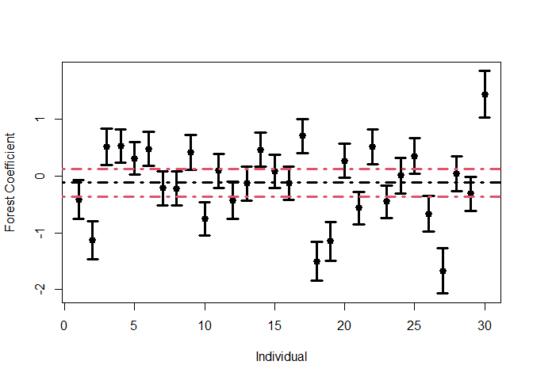

```r
#Plot
  plotCI(x = 1:n.indiv,
         y = indiv.forest.popModel$estimate,
         ui = indiv.forest.popModel$conf.high,
         li = indiv.forest.popModel$conf.low,
         lwd = 3,col=1,
         xlab="Individual",ylab="Forest Coefficient")
  abline(h=pop.coef.popModel$estimate[2],lwd=3,col=1,lty=4)
  abline(h=pop.coef.popModel$conf.low[2],lwd=3,col=2,lty=4)
  abline(h=pop.coef.popModel$conf.high[2],lwd=3,col=2,lty=4)
```

Our plot shows the individual effects of `forest` (vertical lines) along with the population-level mean and confidence intervals (horizontal lines). Compare this output and inference to the figure (right-side) for the pooled model fit at the end of Section 3.11. In the pooled case we would conclude that at the population level, this species avoids forest (i.e., negative coefficient), and we would say that with some level of statistical certainty because the confidence intervals do not include zero. Here we get a more nuanced picture of what’s happening, and that leads to a very different conclusion.

#### 3.12.4 Sample size

The code for implementing the methods of [Street et al. 2021](https://doi.org/10.1111/2041-210X.13701) can be found at [figshare](https://figshare.com/articles/dataset/Datasets_and_Code_zip/11910831).

You can also find an implementation of these methods to calculate the number of individuls tracked/sampled to determine statistical clarity of a hypothesized population mean effect in the `TraditionalHSF.Rmd` file.

### 3.13 13. Considering context in habitat selection analyses

In this section we discuss ways of considering behavior in habitat selection analyses. To demonstrate the effect of ignoring behavior, we will simulate data where selection is different for two sets of animal locations. Imagine an individual is highly selective of forest cover when it is resting, but when foraging (and otherwise) selects against forest cover in proportion to its availability.

```r
  hsf.true.behav = vector("list",2)
  hsf.true.behav[[1]] = covs[[2]]*2
  hsf.true.behav[[2]] = covs[[2]]*-2

  sim.behav1 =  sim.ind.movement.hsf(hsf.true = hsf.true.behav,
                                     n.time = n.time,
                                     n.step = n.step,
                                     n.avail = n.avail,
                                     angle.mean = angle.mean,
                                     angle.kappa = angle.kappa,
                                     step.rate = step.rate
                                     )

# Combine the data
  data.ignore= rbind(sim.behav1$indiv[[1]],
                     sim.behav1$indiv[[2]]
                     )

# Create ID vector for the different behavioral data
  ID=rep(1:2,each = nrow(sim.behav1$indiv[[1]]))
  data.ignore$ID = ID
# Create ID vector for unique strata within individual
  data.ignore$indiv.id.strata=unique(data.ignore$ID+data.ignore$strata*100)
```

Lets fit a model where we ignore the behavioral differences in selection and fit a single model with all the data.

```r
  model.ignore.behav =  clogit(status ~ dist.dev + strata(indiv.id.strata),
                               data = data.ignore
                               )
  summary(model.ignore.behav)
```

```
## Call:
## coxph(formula = Surv(rep(1, 80800L), status) ~ dist.dev + strata(indiv.id.strata),
##     data = data.ignore, method = "exact")
##
##   n= 74794, number of events= 800
##    (6006 observations deleted due to missingness)
##
##              coef exp(coef) se(coef)     z Pr(>|z|)
## dist.dev 0.008814  1.008853 0.035404 0.249    0.803
##
##          exp(coef) exp(-coef) lower .95 upper .95
## dist.dev     1.009     0.9912    0.9412     1.081
##
## Concordance= 0.503  (se = 0.011 )
## Likelihood ratio test= 0.06  on 1 df,   p=0.8
## Wald test            = 0.06  on 1 df,   p=0.8
## Score (logrank) test = 0.06  on 1 df,   p=0.8
```

### 3.14 14. Interpreting coefficients and predicting

Interpreting coefficients and predicting is outlined above in subsection `7. What are habitat-selection functions used for?`.

### 3.15 15. Model selection

If focused on inference, fitting a single model is not only okay, but desirable.

### 3.16 16. Concluding remarks

We hope this vignette proided some utility. If so, let us know with an email (brian.gerber@colostate.edu).

Have a nice day.

## 4 Software

This report was generated from the R Statistical Software (v4.4.2; R Core Team 2021) using the [Markdown language](https://www.markdownguide.org/) and [RStudio](https://posit.co/products/open-source/rstudio/). The R packages used are acknowledged below.

| Package | Version | Citation |
| --- | --- | --- |
| amt | 0.3.0.0 | @amt |
| base | 4.4.2 | @base |
| broom.mixed | 0.2.9.6 | @broommixed |
| circular | 0.5.1 | @circular |
| geoR | 1.9.4 | @geoR |
| glmmTMB | 1.1.10 | @glmmTMB |
| knitr | 1.49 | @knitr2014; @knitr2015; @knitr2024 |
| plotrix | 3.8.4 | @plotrix |
| raster | 3.6.30 | @raster |
| remotes | 2.5.0 | @remotes |
| ResourceSelection | 0.3.6 | @ResourceSelection |
| Rfast | 2.1.0 | @Rfast |
| rmarkdown | 2.29 | @rmarkdown2018; @rmarkdown2020; @rmarkdown2024 |
| sp | 2.1.4 | @sp2005; @sp2013 |
| survival | 3.7.0 | @survival-book; @survival-package |
| tidyverse | 2.0.0 | @tidyverse |